# Abortion and Crime

Matt Taddy

Itamar Caspi

2019-10-19

Abstract

A replication of the abortion and crime example that appear in Matt Taddy’s “Business Data Science”, Chapter 6 under “High-Dimensional Confounder Adjustment.”

## Load required packages

```r
if (!require("pacman")) install.packages("pacman")

pacman::p_load(
  here,        # for referencing files and folders
  tidyverse,   # for data reading wrangling and visualization
  tidymodels,  # for data modeling
  gamlr,       # for running the gamma lasso algorithm
  AER,         # for robust standard errors
  furrr        # for parallel loops
)
```

## The Data

Read the data and rename the variables

```r
abortion_raw <- read_tsv(here("abortion/data", "abortion.dat"))

names(abortion_raw) <- c(
  "state","year","c_pop","y_viol","y_prop","y_murd",
    "a_murd","a_viol","a_prop","c_prison","c_police",
    "c_ur","c_inc","c_pov","c_afdc","c_gun","c_beer"
  )
```

The outcome, `y_murd`, is the de-trended log crime rate. (note we also have violent and property crime versions.)

The abortion `a_*` variables are weighted average of abortion rates where weights are determined by the fraction of the type of crime committed by various age groups. For example, if 60% of violent crime were committed by 18 year olds and 40% were committed by 19 year olds in state $i$, the abortion rate for violent crime at time $t$ in state $i$ would be constructed as .6 times the abortion rate in state $i$ at time $t − 18$ plus 0.4 times the abortion rate in state $i$ at time $t − 19$. See Donohue and Levitt (2001) for further detail.

The set of counfounders, `c_*` variables, includes:

- `c_prison`: log of lagged prisoners per capita
- `c_police`: the log of lagged police per capita
- `c_ur`: the unemployment rate
- `c_inc`: per-capita income
- `c_pov`: the poverty rate
- `c_adfc`: generosity at year t-15
- `c_gun`: dummy for concealed weapons law
- `c_beer`: beer consumption per capita

## Data preprocessing

```r
abortion_df <- abortion_raw %>%
  filter(
    !state %in% c(2,9,12), # AK, DC, HA are strange places
    year %in% 85:97,       # incomplete data outside these years
    ) %>%
  mutate(
    c_pop = log(c_pop),
    t = year - 85,
    s = factor(state)      # the states are numbered alphabetically
  )
```

## Replicating Donohue and Levitt

In our analysis we’ll just look at murder.

The full regression model is then

$$\mathbb{E}\left[y_{s t}\right]=\alpha_{s}+t \delta_{t}+d_{s t} \gamma+\boldsymbol{x}_{s t}^{\prime} \boldsymbol{\beta}$$

We fit using `glm()`

```r
orig_df <- abortion_df %>%
  select(y_murd, a_murd, t, s, c_pop, c_prison:c_beer)

orig_glm <- glm(y_murd ~ ., data = orig_df)

orig_glm %>%
  tidy() %>%
  filter(term == "a_murd")
```

```
## # A tibble: 1 x 5
##   term   estimate std.error statistic     p.value
##   <chr>     <dbl>     <dbl>     <dbl>       <dbl>
## 1 a_murd   -0.210    0.0411     -5.11 0.000000451
```

This is the Levitt analysis: higher abortion leads to lower crime

## Adding Cellphones

That abortion is only one factor influencing crime in the late 1980s points out the caution required in drawing any conclusions regarding an abortion-crime link based on time series evidence alone

Now the same analysis, but for cellphones rather than abortion

```r
cell_raw <- read_csv(here("abortion/data", "us_cellphone.csv"))

cell_df <- cell_raw %>%
  mutate(
    cellrate = 5 * subscribers / (1000 * pop),
    year = year - 1900
  )
```

Merge `cellrate` with the abortion dataset

```r
abortion_cell_df <- abortion_df %>%
  left_join(
    cell_df %>% select(year, cellrate),
    by = "year"
    )
```

What if we’re just fitting a quadratic trend? There are many things that increased with similar shapes over time (cellphone usage, yoga revenues, home prices, …)

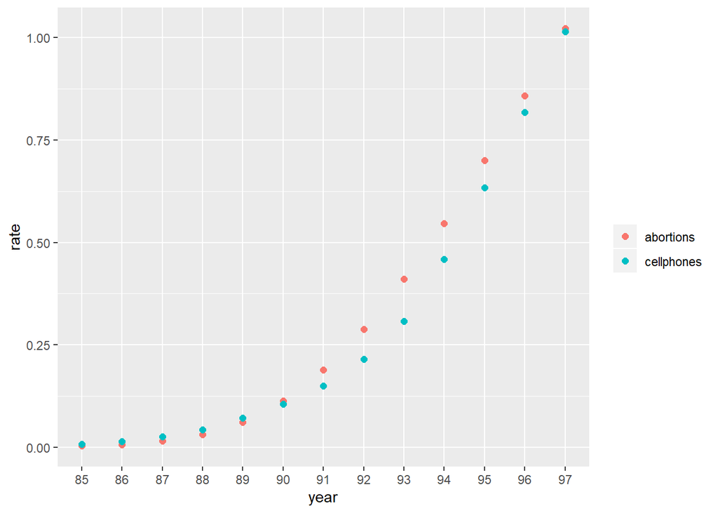

```r
abortion_cell_yearly <- abortion_cell_df %>%
  group_by(year) %>%
  summarise(abortions = mean(a_murd),
            cellphones = mean(cellrate)) %>%
  pivot_longer(-year, names_to = "treatment", values_to = "value")

abortion_cell_yearly %>%
  ggplot(aes(x = as_factor(year), y = value, color = treatment)) +
  geom_point(size = 2) +
  labs(x = "year",
       y = "rate",
       color = "")
```

Estimate a regression where `phones` is defined as the treatment variable

```r
tech_df <- abortion_cell_df %>%
  select(y_murd, a_murd, cellrate, t, s, c_pop, c_prison:c_beer) %>%
  rename(phone = cellrate)


tech_glm <- glm(y_murd ~ . - a_murd, data = tech_df)

tech_glm %>%
  tidy() %>%
  filter(term == "phone")
```

```
## # A tibble: 1 x 5
##   term  estimate std.error statistic     p.value
##   <chr>    <dbl>     <dbl>     <dbl>       <dbl>
## 1 phone   -0.372    0.0693     -5.37 0.000000117
```

What is happening here is that murder has been increasing quadratically, and we have no other controls that do so. To be correct, you need to allow quadratic trends that could be caused by other confounding variables (e.g. technology), we also allow interaction between the controls, and interact the nation-wide phone variable with state dummies to allow for state specific tech adoption.

```r
interact_df <- tech_df %>%
  mutate(t = as_factor(t)) %>%
  recipe(y_murd ~ .) %>%
  step_dummy(all_nominal()) %>%
  step_interact(~ starts_with("s_"):phone) %>%
  step_interact(~ starts_with("c_"):starts_with("c_")) %>%
  step_zv(all_predictors()) %>%
  prep() %>%
  juice()

interact_glm <- glm(y_murd ~ ., data = interact_df)

interact_glm %>%
  tidy() %>%
  filter(term == "a_murd")
```

```
## # A tibble: 1 x 5
##   term   estimate std.error statistic p.value
##   <chr>     <dbl>     <dbl>     <dbl>   <dbl>
## 1 a_murd    0.280     0.181      1.55   0.122
```

Abortion sign has switched direction (and is insignificant)!

## LTE Lasso Regression

We have very few observations relative to number of parameters, so we need a way to select only important controls. We try using a lasso.

Define the data to be used in the lasso

```r
lasso_df <- tech_df %>%
  mutate(t = as_factor(t)) %>%
  recipe(y_murd ~ .) %>%
  step_dummy(all_nominal(), one_hot = TRUE) %>%
  step_interact(~ starts_with("s_"):phone) %>%
  step_interact(~ starts_with("c_"):starts_with("c_")) %>%
  step_zv(all_predictors()) %>%
  prep() %>%
  juice()

head(lasso_df)
```

```
## # A tibble: 6 x 157
##    a_murd   phone c_pop c_prison c_police   c_ur c_inc c_pov c_afdc c_gun
##     <dbl>   <dbl> <dbl>    <dbl>    <dbl>  <dbl> <dbl> <dbl>  <dbl> <dbl>
## 1 8.60e-4 0.00715  8.29    0.953    0.763 0.0891  9.70  20.6  3078.     1
## 2 1.35e-3 0.0142   8.29    0.995    0.791 0.0983  9.75  23.8  2806.     1
## 3 5.25e-3 0.0254   8.30    1.06     0.819 0.0778  9.76  21.3  3456.     1
## 4 9.68e-3 0.0423   8.30    1.14     0.880 0.0721  9.78  19.3  3210      1
## 5 2.22e-2 0.0711   8.30    1.12     0.941 0.0703  9.80  18.9  3789.     1
## 6 4.58e-2 0.106    8.31    1.21     0.989 0.0678  9.81  19.2  3437.     1
## # ... with 147 more variables: c_beer <dbl>, y_murd <dbl>, t_X0 <dbl>,
## #   t_X1 <dbl>, t_X2 <dbl>, t_X3 <dbl>, t_X4 <dbl>, t_X5 <dbl>,
## #   t_X6 <dbl>, t_X7 <dbl>, t_X8 <dbl>, t_X9 <dbl>, t_X10 <dbl>,
## #   t_X11 <dbl>, t_X12 <dbl>, s_X1 <dbl>, s_X3 <dbl>, s_X4 <dbl>,
## #   s_X5 <dbl>, s_X6 <dbl>, s_X7 <dbl>, s_X8 <dbl>, s_X10 <dbl>,
## #   s_X11 <dbl>, s_X13 <dbl>, s_X14 <dbl>, s_X15 <dbl>, s_X16 <dbl>,
## #   s_X17 <dbl>, s_X18 <dbl>, s_X19 <dbl>, s_X20 <dbl>, s_X21 <dbl>,
## #   s_X22 <dbl>, s_X23 <dbl>, s_X24 <dbl>, s_X25 <dbl>, s_X26 <dbl>,
## #   s_X27 <dbl>, s_X28 <dbl>, s_X29 <dbl>, s_X30 <dbl>, s_X31 <dbl>,
## #   s_X32 <dbl>, s_X33 <dbl>, s_X34 <dbl>, s_X35 <dbl>, s_X36 <dbl>,
## #   s_X37 <dbl>, s_X38 <dbl>, s_X39 <dbl>, s_X40 <dbl>, s_X41 <dbl>,
## #   s_X42 <dbl>, s_X43 <dbl>, s_X44 <dbl>, s_X45 <dbl>, s_X46 <dbl>,
## #   s_X47 <dbl>, s_X48 <dbl>, s_X49 <dbl>, s_X50 <dbl>, s_X51 <dbl>,
## #   s_X1_x_phone <dbl>, s_X3_x_phone <dbl>, s_X4_x_phone <dbl>,
## #   s_X5_x_phone <dbl>, s_X6_x_phone <dbl>, s_X7_x_phone <dbl>,
## #   s_X8_x_phone <dbl>, s_X10_x_phone <dbl>, s_X11_x_phone <dbl>,
## #   s_X13_x_phone <dbl>, s_X14_x_phone <dbl>, s_X15_x_phone <dbl>,
## #   s_X16_x_phone <dbl>, s_X17_x_phone <dbl>, s_X18_x_phone <dbl>,
## #   s_X19_x_phone <dbl>, s_X20_x_phone <dbl>, s_X21_x_phone <dbl>,
## #   s_X22_x_phone <dbl>, s_X23_x_phone <dbl>, s_X24_x_phone <dbl>,
## #   s_X25_x_phone <dbl>, s_X26_x_phone <dbl>, s_X27_x_phone <dbl>,
## #   s_X28_x_phone <dbl>, s_X29_x_phone <dbl>, s_X30_x_phone <dbl>,
## #   s_X31_x_phone <dbl>, s_X32_x_phone <dbl>, s_X33_x_phone <dbl>,
## #   s_X34_x_phone <dbl>, s_X35_x_phone <dbl>, s_X36_x_phone <dbl>,
## #   s_X37_x_phone <dbl>, s_X38_x_phone <dbl>, s_X39_x_phone <dbl>,
## #   s_X40_x_phone <dbl>, ...
```

Generate the input to be used in the `cv.gamlr()` function

```r
d_X <- lasso_df %>% select(-y_murd)
X   <- lasso_df %>% select(-y_murd, -a_murd)
d   <- lasso_df %>% select(a_murd)
y   <- lasso_df %>% select(y_murd)
```

A naive lasso regression

```r
naive <- cv.gamlr(x = d_X, y = y)
coef(naive)["a_murd",]
```

```
## [1] -0.04619847
```

The effect is CV selected and negative

Now, what if we explicitly include $\hat{d}$?

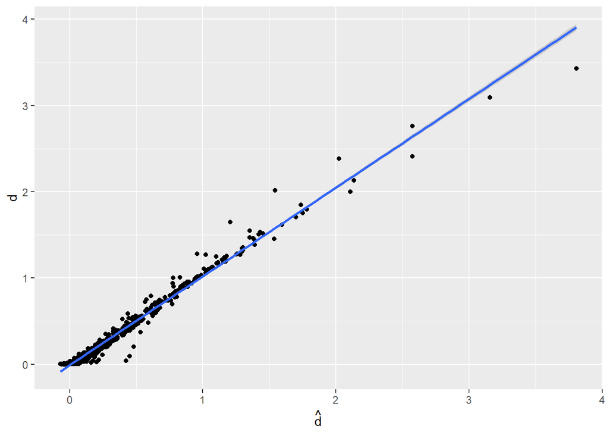

```r
treat <- cv.gamlr(x = X, y = d)

dhat <- tibble(a_murd_hat = drop(predict(treat, X, select = "min")))

bind_cols(d, dhat) %>%
  ggplot(aes(x = a_murd_hat, y = a_murd)) +
  geom_point() +
  geom_smooth(method = "lm") +
  labs(x = expression(hat(d)),
       y = expression(d))
```

Not much signal in $d$ not predicted by $\hat{d}$. That means we have little to resemble an experiment here.

Re-run lasso, with $\hat{d}$ included *unpenalized*

```r
causal <- cv.gamlr(x = bind_cols(d, dhat, X),
                   y = y,
                   free = 2,
                   lmr = 1e-3)

coef(causal, select="min")["a_murd",]
```

```
## [1] 0
```

Thus, the LTE lasso procedure finds no evidence for effect of abortion on murder.

## Orthogonal ML

Split the data to $K=5$ independent folds indexed by $k=1,\dots,5$, and each fold to training and test sets

```r
n_folds <- 5

crossfit_folds <- lasso_df %>%
  vfold_cv(v = n_folds) %>%
  mutate(train = map(splits, ~ training(.x)),
         test  = map(splits, ~ testing(.x)))

crossfit_folds
```

```
## #  5-fold cross-validation
## # A tibble: 5 x 4
##   splits            id    train                test
## * <named list>      <chr> <named list>         <named list>
## 1 <split [499/125]> Fold1 <tibble [499 x 157]> <tibble [125 x 157]>
## 2 <split [499/125]> Fold2 <tibble [499 x 157]> <tibble [125 x 157]>
## 3 <split [499/125]> Fold3 <tibble [499 x 157]> <tibble [125 x 157]>
## 4 <split [499/125]> Fold4 <tibble [499 x 157]> <tibble [125 x 157]>
## 5 <split [500/124]> Fold5 <tibble [500 x 157]> <tibble [124 x 157]>
```

Prepare data for the orthogonal ML for LTE algorithm

```r
crossfit_df <- crossfit_folds %>%
  mutate(
    X = map(train, ~ select(., -y_murd, -a_murd)),
    d = map(train, ~ select(., a_murd)),
    y = map(train, ~ select(., y_murd)),
    X_test = map(test, ~ select(., -y_murd, -a_murd)),
    d_test = map(test, ~ select(., a_murd)),
    y_test = map(test, ~ select(., y_murd))
  )
```

Apply the orthogonal ML algorithm

```r
crossfit_est <- crossfit_df %>%
  mutate(
    # step 1: fit the prediction functions using the training set
    dfit = map2(X, d, ~ cv.gamlr(x = .x, y = .y, lmr=1e-5)),
    yfit = map2(X, y, ~ cv.gamlr(x = .x, y = .y, lmr=1e-5)),
    # step 2: form prediction on the test set
    dhat = map2(dfit, X_test, ~ drop(predict(.x, .y))),
    yhat = map2(yfit, X_test, ~ drop(predict(.x, .y))),
    # step 3: calculate out-of-sample residuals
    dtil   = map2(d_test, dhat, ~ .x - .y),
    ytil   = map2(y_test, yhat, ~ .x - .y),
    til_df = map2(ytil, dtil, ~ bind_cols(.x, .y)),
  )
```

Collect all of the out-of-sample residuals from the nuisance stage, and use OLS to fit the regression
$$\mathbb{E}[\tilde{y} | \tilde{d}]=\alpha+\tilde{d} \gamma$$

```r
orth_ml_df <- crossfit_est %>%
  select(til_df) %>%
  unnest(til_df)

rfit <- lm(y_murd ~ a_murd, data = orth_ml_df)

rfit %>%
  coeftest(vcov = vcovHC(rfit)) %>%
  tidy() %>%
  filter(term == "a_murd")
```

```
## # A tibble: 1 x 5
##   term   estimate std.error statistic p.value
##   <chr>     <dbl>     <dbl>     <dbl>   <dbl>
## 1 a_murd -0.00840     0.110   -0.0766   0.939
```

## Appendix: Accounting for Uncertainty Due to Sample-Splitting

We write a function that accepts a `rsplit` object and returns a tibble with the orthogonalized $y$ and $d$. This function will allow us to run our code in parallel.

```r
orth_ml <- function(split, outcome, treatment) {

  # tidy evaluation of arguments
  outcome   <- enquo(outcome)
  treatment <- enquo(treatment)
  # generate training and testing set
  training <- split %>% training()
  testing  <- split %>% testing()
  # step 1: fit the prediction functions using the training set
  d_fit <- cv.gamlr(
    x = training %>% select(- !! outcome, - !! treatment),
    y = training %>% select(!! treatment)
  )
  y_fit <- cv.gamlr(
    x = training %>% select(- !! outcome, - !! treatment),
    y = training %>% select(!! outcome)
  )
  # step 2: form prediction on the test set
  d_hat <- d_fit %>%
    predict(newdata = testing %>% select(- !! outcome, - !! treatment)) %>%
    drop()
  y_hat <- y_fit %>%
    predict(newdata = testing %>% select(- !! outcome, - !! treatment)) %>%
    drop()
  # step 3: calculate out-of-sample residuals
  d_test <- testing %>% select(!! treatment)
  y_test <- testing %>% select(!! outcome)
  d_til <- d_test - d_hat
  y_til <- y_test - y_hat

  return(bind_cols(y_til, d_til))

}
```

Generate repeated 100 replications of the data, each with a random split to 5 folds

```r
n_splits <- 100 # number of replications
n_folds  <- 5 # number of folds

splits <- lasso_df %>%
  vfold_cv(v = n_folds, repeats = n_splits)

splits
```

```
## #  5-fold cross-validation repeated 100 times
## # A tibble: 500 x 3
##    splits            id        id2
##    <named list>      <chr>     <chr>
##  1 <split [499/125]> Repeat001 Fold1
##  2 <split [499/125]> Repeat001 Fold2
##  3 <split [499/125]> Repeat001 Fold3
##  4 <split [499/125]> Repeat001 Fold4
##  5 <split [500/124]> Repeat001 Fold5
##  6 <split [499/125]> Repeat002 Fold1
##  7 <split [499/125]> Repeat002 Fold2
##  8 <split [499/125]> Repeat002 Fold3
##  9 <split [499/125]> Repeat002 Fold4
## 10 <split [500/124]> Repeat002 Fold5
## # ... with 490 more rows
```

Generate are the orthogonalized residuals, sorted by replication

```r
plan(multiprocess) # use multiple cores

resids <- splits %>%
  mutate(df = future_map(
    splits, ~ orth_ml(., outcome = y_murd, treatment = a_murd))
  ) %>%
  select(id, df) %>%
  unnest(df)

head(residuals)
```

```
##
## 1 function (object, ...)
## 2 UseMethod("residuals")
```

Estimate the treatment effect for each replication

```r
coefs <- resids %>%
  nest(data = c(y_murd, a_murd)) %>%
  mutate(
    rfit = map(data, ~ lm(y_murd ~ a_murd, data = .)),
    coef = map(rfit, ~ tidy(coeftest(., vcov = vcovHC(.))))
  ) %>%
  unnest(coef) %>%
  select(id, term, estimate, std.error) %>%
  filter(term == "a_murd")

coefs
```

```
## # A tibble: 100 x 4
##    id        term   estimate std.error
##    <chr>     <chr>     <dbl>     <dbl>
##  1 Repeat001 a_murd  -0.176     0.103
##  2 Repeat002 a_murd  -0.0964    0.117
##  3 Repeat003 a_murd   0.0319    0.158
##  4 Repeat004 a_murd   0.0529    0.148
##  5 Repeat005 a_murd  -0.0775    0.0828
##  6 Repeat006 a_murd  -0.0398    0.132
##  7 Repeat007 a_murd  -0.287     0.181
##  8 Repeat008 a_murd  -0.0689    0.0990
##  9 Repeat009 a_murd   0.0213    0.128
## 10 Repeat010 a_murd  -0.0352    0.131
## # ... with 90 more rows
```

Now, following Chernozhukov et al., (2018) we define the mean estimator for $\gamma$ as the average $\gamma$ across $s=1, \dots, S$ replications, i.e.,

$$\widehat{\gamma}_{\text{MEAN}}=\frac{1}{S} \sum_{s=1}^{S} \widehat{\gamma}_{(s)}$$

and the estimator for the variance is defined as

$$\widehat{\sigma}_{\text{MEAN}}^{2}=\frac{1}{S} \sum_{s=1}^{S} \widehat{\sigma}^{2}_{(s)}+\frac{1}{S}\left\{\sum_{s=1}^{S} {\left(\widehat{\gamma}_{(s)}-\widehat{\gamma}_{\text{MEAN}}\right)^{2}}\right\}$$

where $\widehat{\gamma}_{(s)}$ and $\widehat{\sigma}^{2}_{(s)}$ are the ATE and its corresponding variance that are estimated using the $s^{\text{th}}$ replication of the data.

Plot the distribution of $\widehat{\gamma}_{(s)}$

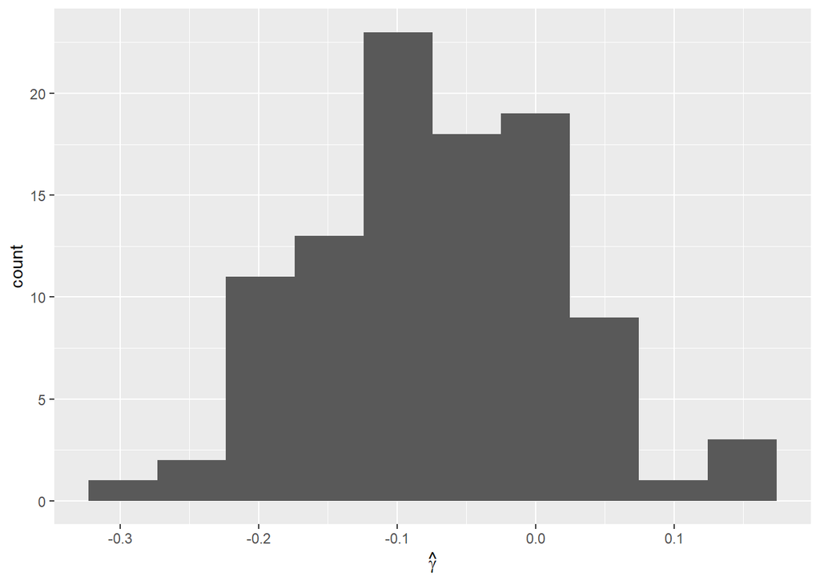

```r
coefs %>%
  ggplot(aes(estimate)) +
  geom_histogram(bins = 10) +
  labs(x = expression(hat(gamma)))
```

Finally, calculate $\widehat{\gamma}_{\text{MEAN}}$ and $\widehat{\sigma}_{\text{MEAN}}$

```r
coefs %>%
  mutate(
    var_1st_term = std.error^2,
    var_2nd_term = (estimate - mean(estimate))^2,
    var_2nd_term_median = (estimate - median(estimate))^2,
  ) %>%
  summarise(
    gamma_mean   = mean(estimate),
    se_mean      = sqrt(mean(var_1st_term + var_2nd_term)),
    gamma_median = median(estimate),
    se_median    = median(sqrt(var_1st_term + var_2nd_term_median))
  )
```

```
## # A tibble: 1 x 4
##   gamma_mean se_mean gamma_median se_median
##        <dbl>   <dbl>        <dbl>     <dbl>
## 1    -0.0733   0.150      -0.0749     0.140
```

Note that we’ve also included the median version of the above estimators that are more robust to extreme point estimates obtained in the different random partitions of the data.

## References

Chernozhukov, V., Chetverikov, D., Demirer, M., Duflo, E., Hansen, C., Newey, W., & Robins, J. (2018). Double/debiased machine learning for treatment and structural parameters. *The Econometrics Journal*, 21(1), C1-C68.

Donohue III, J. J., & Levitt, S. D. (2001). The impact of legalized abortion on crime. *The Quarterly Journal of Economics*, 116(2), 379-420.

Taddy, M. *Business Data Science: Combining Machine Learning and Economics to Optimize, Automate, and Accelerate Business Decisions* . McGraw-Hill Education.